# Optimizing a Nasdaq Portfolio

## J. Alejandro Gelves

This script shows how to construct a porfolio of stocks in the nasdaq that yield a certain amount of return with a minimium risk. Start by loading the packages.

```python
import numpy as np
import mysql.connector
import pandas as pd
from gurobipy import *
import matplotlib.pyplot as plt
```

The data is in an SQL database. So we establish the connection to the database and enable the cursor.

```python
db=mysql.connector.connect(host='localhost',user='root',passwd='',database='nasdaq')
cur=db.cursor()
```

Now that we have the connection, we can get the desired data. Mainly, we need the monthly returns, the name of the stocks and the covariance matrix of the returns.

```python
# Get the returns
cur.execute('SELECT meanReturn FROM nasdaq.r')
returns=cur.fetchall()
returns=np.matrix(returns)
maxreturns = float(max(returns))
minreturns = float(min(returns))

# Get the Stock names
cur.execute('SELECT stock FROM nasdaq.r')
stocks=cur.fetchall()
stock=[]
for i in stocks:
  for a in i:
    stock.append(a)

# Get the covariance
cur.execute('SELECT * FROM nasdaq.cov')
cov=cur.fetchall()
n = len(cov)
cov=np.matrix(cov)
covmatrix=np.zeros((int(cov[n-1,0]),int(cov[n-1,1])))
print(cov[1,0])
for i in range(0,n):
    j=int(cov[i,0])-1
    k=int(cov[i,1])-1
    covmatrix[j,k]=float(cov[i,2])
    covmatrix[k,j]=covmatrix[j,k]
```

Now that we have the data, we use gorobi to minimize the risk in the portfolio. We set the model.

```python
m = Model("Investments")
m.ModelSense = GRB.MINIMIZE
m.setParam("TimeLimit", 7200)
```

We want to choose the fraction of each investment that should be held to yield a given expected return i at minimum risk. These are our choice variables.

```python
variables = pd.Series(m.addVars(stock,vtype=GRB.CONTINUOUS,lb=0.0,ub=1.0), index=stock)
m.update()

# Creating a numpy matrix for the fractions of investments. Creating the expected profit.
fractions=np.matrix(variables)
sfractions=sum(fractions).item(0)
exprofit=fractions*returns
```

Finally, we create the objective function (risk) and calculate the profolio for 20 different inteval between the minimum and max returns possible in the portfolio.

```python
# Creating the objective function
objrisk=fractions*covmatrix*np.transpose(fractions)

portfolio=[]
iterations = 20
targets=np.arange(minreturns,maxreturns,(maxreturns -minreturns)/iterations)
for i in targets:
  # Add the constraints
  m.addConstr(variables.sum() == 1, "Budget")
  m.addConstr(exprofit.item(0), GRB.GREATER_EQUAL, i, "ExpProfit")

  # The objective function
  m.setObjective(objrisk.item(0), GRB.MINIMIZE)
  m.update()
  m.optimize()
  portfolio.append([i,m.getObjective().getValue()])
cur.close()
db.close()
```

[output not shown]

[output cut: 624 more lines]

[output not shown]

Finally, we can plot the results of the optimization. Specifically, the efficient frontier shows the realtionship between the expected return and the risk.

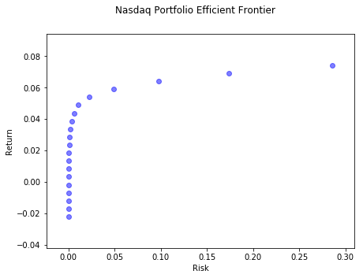

```python
frontier=pd.DataFrame(portfolio)
frontier.columns=['Return','Risk']

fig, ax = plt.subplots()

ax.scatter(frontier['Risk'], frontier['Return'], alpha=0.5, c = 'b')
fig.suptitle('Nasdaq Portfolio Efficient Frontier')
ax.xaxis.set_label_text('Risk')
ax.yaxis.set_label_text('Return')
fig.set_size_inches(7,5)
plt.show()
```